# BIOSTAT 707 Checkpoint 1: cohort characterization and EDA

Author

Yifei Chen

Published

September 21, 2026

```r
library(data.table)
library(dplyr)
library(tidyr)
library(readr)
library(ggplot2)
here::i_am("checkpoint1.qmd")
data_dir <- here::here("data")
out_dir <- here::here("output")
dir.create(out_dir, showWarnings = FALSE)
expected_n <- 4000L

first_valid <- function(x) {
  x <- x[!is.na(x)]
  if (length(x)) x[[1]] else NA_real_
}
last_valid <- function(x) {
  x <- x[!is.na(x)]
  if (length(x)) x[[length(x)]] else NA_real_
}
min_valid <- function(x) if (all(is.na(x))) NA_real_ else min(x, na.rm = TRUE)
max_valid <- function(x) if (all(is.na(x))) NA_real_ else max(x, na.rm = TRUE)
mean_valid <- function(x) if (all(is.na(x))) NA_real_ else mean(x, na.rm = TRUE)
```

# Data and analysis plan

This report describes the 4,000 ICU stays in Challenge 2012 Set A. Each record contains observations from the first 48 hours after ICU admission. The outcome file is joined for description, while its post-admission fields are kept separate from candidate predictors. The input files come from the [PhysioNet Challenge 2012 dataset](https://physionet.org/content/challenge-2012/1.0.0/) (Silva et al., 2012; full citations below). All file paths are relative to this repository. The analysis reads `data/` and writes derived files only to `output/`.

```r
files <- list.files(
  file.path(data_dir, "set-a"), pattern = "^[0-9]+\\.txt$", full.names = TRUE
)
stopifnot(
  "Expected 4,000 Set A record files" = length(files) == expected_n,
  "Outcomes-a.txt is missing" = file.exists(file.path(data_dir, "Outcomes-a.txt"))
)
outcomes <- readr::read_csv(
  file.path(data_dir, "Outcomes-a.txt"), show_col_types = FALSE
)
stopifnot(
  "Expected 4,000 outcome rows" = nrow(outcomes) == expected_n,
  "Outcome IDs must be unique" = n_distinct(outcomes$RecordID) == expected_n,
  "Outcome labels must be binary" = all(outcomes$`In-hospital_death` %in% c(0, 1))
)
```

# The long table

Each record file has `Time`, `Parameter`, and `Value` columns. The filename and the `RecordID` line within the file must agree. `RecordID` becomes a column, so that identifying line is omitted from the measurement rows. The original value is retained in `Value_raw`; `Value` is the analysis value. PhysioNet defines `-1` as missing or unknown and says valid values are nonnegative. Therefore all negative values, including other negative codes, become `NA` in `Value`.

```r
read_record <- function(path) {
  x <- data.table::fread(path, showProgress = FALSE)
  if (!identical(names(x), c("Time", "Parameter", "Value"))) {
    stop("Unexpected columns in ", basename(path))
  }
  id <- as.integer(tools::file_path_sans_ext(basename(path)))
  embedded_id <- x[Parameter == "RecordID", Value]
  if (length(embedded_id) != 1L || embedded_id != id) {
    stop("RecordID mismatch in ", basename(path))
  }
  x[, RecordID := id]
  x
}
long <- data.table::rbindlist(lapply(files, read_record), use.names = TRUE) |>
  tibble::as_tibble() |>
  filter(Parameter != "RecordID") |>
  mutate(
    hour = as.numeric(substr(Time, 1, 2)) +
      as.numeric(substr(Time, 4, 5)) / 60,
    Value_raw = as.numeric(Value),
    Value = if_else(Value_raw < 0, NA_real_, Value_raw)
  ) |>
  select(RecordID, Time, hour, Parameter, Value_raw, Value)
stopifnot(
  "Some times could not be parsed" = !anyNA(long$hour),
  "Times must be within the first 48 hours" = all(between(long$hour, 0, 48)),
  "Record IDs differ from outcomes" = setequal(unique(long$RecordID), outcomes$RecordID)
)
readr::write_csv(long, file.path(out_dir, "set-a_long.csv"))
```

The long table contains 1,753,980 measurement rows from 4000 stays and 41 measurement parameters. There are 2,223 explicit `-1` entries and 24 other negative entries.

# Data quality and decisions

The following table shows the negative values other than `-1`. Because the source documentation says valid measurements are nonnegative, these values are also treated as missing in `Value`, while `Value_raw` preserves the evidence.

```r
invalid_negative <- long |>
  filter(Value_raw < 0, Value_raw != -1) |>
  count(Parameter, Value_raw, name = "Rows", sort = TRUE)
knitr::kable(invalid_negative, caption = "Negative values other than the documented -1 code")
```

Negative values other than the documented -1 code

| Parameter | Value_raw | Rows |
| --- | --- | --- |
| Temp | -17.8 | 23 |
| Temp | -12.5 | 1 |

The next summaries expose unusual nonnegative values. The ranges are *review flags*, not automatic deletion rules: severe illness and measurement error can both produce extreme readings. We retain these values in the derived tables and make that choice explicit. An individual value needs clinical and source-data review before a later modeling analysis decides whether to exclude it.

```r
parameter_ranges <- long |>
  group_by(Parameter) |>
  summarise(
    rows = n(), missing_or_invalid = sum(is.na(Value)),
    minimum = min_valid(Value), median = if (all(is.na(Value))) NA_real_ else median(Value, na.rm = TRUE),
    maximum = max_valid(Value), .groups = "drop"
  ) |>
  arrange(Parameter)
knitr::kable(parameter_ranges, digits = 2,
             caption = "Observed ranges after documented and invalid negative values are set to missing")
```

Observed ranges after documented and invalid negative values are set to missing

| Parameter | rows | missing_or_invalid | minimum | median | maximum |
| --- | --- | --- | --- | --- | --- |
| ALP | 3092 | 0 | 12.00 | 82.00 | 2205.00 |
| ALT | 3177 | 0 | 1.00 | 43.00 | 11470.00 |
| AST | 3182 | 0 | 4.00 | 64.00 | 18430.00 |
| Age | 4000 | 0 | 15.00 | 67.00 | 90.00 |
| Albumin | 2356 | 0 | 1.00 | 2.90 | 5.30 |
| BUN | 13916 | 0 | 0.00 | 20.00 | 197.00 |
| Bilirubin | 3191 | 0 | 0.10 | 0.90 | 47.70 |
| Cholesterol | 315 | 0 | 28.00 | 152.00 | 330.00 |
| Creatinine | 13983 | 0 | 0.10 | 1.00 | 22.10 |
| DiasABP | 145567 | 0 | 0.00 | 58.00 | 268.00 |
| FiO2 | 32390 | 0 | 0.21 | 0.50 | 1.00 |
| GCS | 61563 | 0 | 3.00 | 13.00 | 15.00 |
| Gender | 4000 | 3 | 0.00 | 1.00 | 1.00 |
| Glucose | 13021 | 0 | 10.00 | 127.00 | 1143.00 |
| HCO3 | 13613 | 0 | 5.00 | 23.00 | 50.00 |
| HCT | 18271 | 0 | 9.00 | 30.30 | 61.80 |
| HR | 228538 | 0 | 0.00 | 86.00 | 300.00 |
| Height | 4000 | 1894 | 1.80 | 170.20 | 431.80 |
| ICUType | 4000 | 0 | 1.00 | 3.00 | 4.00 |
| K | 14440 | 0 | 1.80 | 4.10 | 22.90 |
| Lactate | 8024 | 0 | 0.30 | 2.10 | 29.30 |
| MAP | 145760 | 0 | 0.00 | 77.00 | 300.00 |
| MechVent | 31144 | 0 | 1.00 | 1.00 | 1.00 |
| Mg | 13590 | 0 | 0.60 | 2.00 | 9.90 |
| NIDiasABP | 98210 | 0 | 0.00 | 56.00 | 201.00 |
| NIMAP | 96871 | 0 | 0.00 | 75.00 | 209.00 |
| NISysABP | 98331 | 0 | 0.00 | 116.00 | 296.00 |
| Na | 13570 | 0 | 98.00 | 139.00 | 177.00 |
| PaCO2 | 23293 | 0 | 0.30 | 39.00 | 100.00 |
| PaO2 | 23268 | 0 | 0.00 | 121.00 | 500.00 |
| Platelets | 14104 | 0 | 6.00 | 172.00 | 1047.00 |
| RespRate | 55051 | 0 | 0.00 | 19.00 | 98.00 |
| SaO2 | 8185 | 0 | 26.00 | 97.00 | 100.00 |
| SysABP | 145650 | 0 | 0.00 | 116.00 | 295.00 |
| Temp | 86405 | 24 | 0.00 | 37.10 | 42.10 |
| TroponinI | 435 | 0 | 0.30 | 2.60 | 49.20 |
| TroponinT | 2126 | 0 | 0.01 | 0.20 | 24.91 |
| Urine | 136918 | 0 | 0.00 | 70.00 | 11000.00 |
| WBC | 12910 | 0 | 0.10 | 11.40 | 187.50 |
| Weight | 129165 | 326 | 0.00 | 80.70 | 300.00 |
| pH | 24355 | 0 | 1.00 | 7.38 | 735.00 |

```r
bounds <- tibble::tribble(
  ~Parameter, ~lower, ~upper,
  "Age", 18, 120,
  "Height", 100, 230,
  "Weight", 20, 400,
  "HR", 20, 250,
  "RespRate", 4, 60,
  "Temp", 30, 43,
  "pH", 6.8, 7.8,
  "GCS", 3, 15,
  "FiO2", 0, 1,
  "SaO2", 50, 100,
  "Gender", 0, 1,
  "ICUType", 1, 4
)
flags <- long |>
  inner_join(bounds, by = "Parameter") |>
  filter(!is.na(Value), Value < lower | Value > upper) |>
  group_by(Parameter) |>
  summarise(flagged_rows = n(), smallest = min(Value), largest = max(Value),
            .groups = "drop") |>
  arrange(desc(flagged_rows))
knitr::kable(flags, digits = 2,
             caption = "Values outside broad screening ranges, retained for review")
```

Values outside broad screening ranges, retained for review

| Parameter | flagged_rows | smallest | largest |
| --- | --- | --- | --- |
| Weight | 235 | 0.0 | 3.4 |
| Temp | 109 | 0.0 | 29.9 |
| RespRate | 68 | 0.0 | 98.0 |
| HR | 17 | 0.0 | 300.0 |
| Height | 16 | 1.8 | 431.8 |
| pH | 11 | 1.0 | 735.0 |
| SaO2 | 8 | 26.0 | 47.0 |
| Age | 6 | 15.0 | 17.0 |

These flags include values that may be recording errors, for example a zero body temperature or a pH far below a plausible physiological range. They are not silently recoded because the documentation gives no correction rule for such nonnegative entries. Median summaries below are less sensitive to isolated extremes than means, but the wide file retains both summaries for inspection.

# Missingness over time in the long table

An absent row is not marked `NA` in a patient’s file. To represent missingness, we ask whether each admission has **at least one valid measurement** of each time-series parameter in each two-hour interval. The denominator is all 4000 admissions, including those with no row for that parameter. The final observation at hour 48 belongs to the last interval.

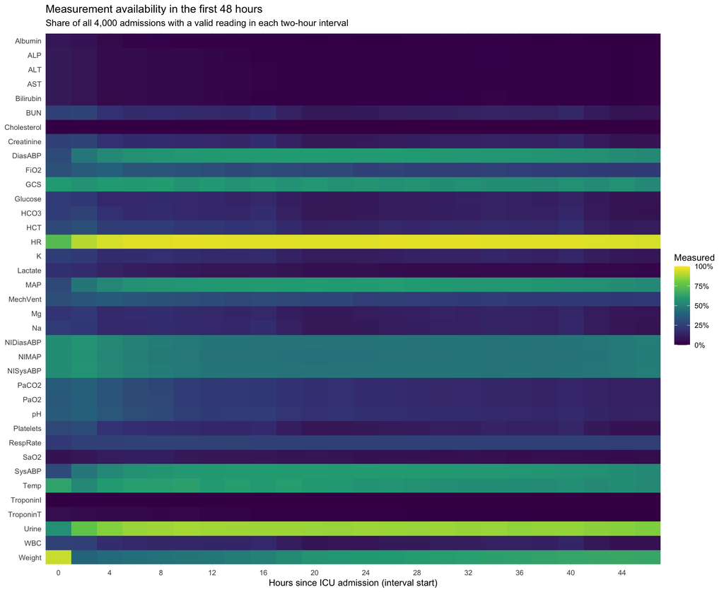

```r
time_series_parameters <- sort(setdiff(
  unique(long$Parameter), c("Age", "Gender", "Height", "ICUType")
))
temporal <- long |>
  filter(Parameter %in% time_series_parameters, !is.na(Value)) |>
  mutate(bin = pmin(floor(hour / 2), 23L)) |>
  distinct(RecordID, Parameter, bin) |>
  count(Parameter, bin, name = "admissions_measured")
temporal <- tidyr::expand_grid(
  Parameter = time_series_parameters, bin = 0:23
) |>
  left_join(temporal, by = c("Parameter", "bin")) |>
  mutate(
    admissions_measured = replace_na(admissions_measured, 0L),
    proportion_measured = admissions_measured / expected_n,
    Parameter = factor(Parameter, levels = rev(time_series_parameters))
  )
ggplot(temporal, aes(x = bin * 2, y = Parameter, fill = proportion_measured)) +
  geom_tile() +
  scale_x_continuous(breaks = seq(0, 46, by = 4), expand = c(0, 0)) +
  scale_fill_viridis_c(labels = scales::label_percent(), limits = c(0, 1)) +
  labs(title = "Measurement availability in the first 48 hours",
       subtitle = "Share of all 4,000 admissions with a valid reading in each two-hour interval",
       x = "Hours since ICU admission (interval start)", y = NULL,
       fill = "Measured") +
  theme_minimal(base_size = 10)
```

This graph describes the *measurement process*, not just explicit `-1` codes. Variables with sparse or changing coverage may reflect clinical decisions about testing as well as gaps in recording. The map does not establish why a measurement is absent.

# The wide table

The wide table has one row per admission. Admission descriptors come from the `00:00` entries. For each time-series parameter, it includes count, first, last, minimum, maximum, and mean of valid readings in **0 to under 24 hours** and **24 through 48 hours**. This preserves some change over time. A count of zero means the variable was not validly measured in that window; its other summaries remain missing. No imputation is performed.

```r
static_parameters <- c("Age", "Gender", "Height", "ICUType", "Weight")
static <- long |>
  filter(hour == 0, Parameter %in% static_parameters) |>
  group_by(RecordID, Parameter) |>
  summarise(Value = first_valid(Value), .groups = "drop") |>
  pivot_wider(names_from = Parameter, values_from = Value)
static <- tibble::tibble(RecordID = outcomes$RecordID) |>
  left_join(static, by = "RecordID")

series_summaries <- long |>
  filter(Parameter %in% time_series_parameters) |>
  mutate(window = if_else(hour < 24, "h00_24", "h24_48")) |>
  arrange(RecordID, Parameter, hour) |>
  group_by(RecordID, Parameter, window) |>
  summarise(
    count = sum(!is.na(Value)),
    first = first_valid(Value), last = last_valid(Value),
    min = min_valid(Value), max = max_valid(Value), mean = mean_valid(Value),
    .groups = "drop"
  )
series_complete <- tidyr::expand_grid(
  RecordID = outcomes$RecordID,
  Parameter = time_series_parameters,
  window = c("h00_24", "h24_48")
) |>
  left_join(series_summaries, by = c("RecordID", "Parameter", "window")) |>
  mutate(count = replace_na(count, 0L))
wide_measurements <- series_complete |>
  pivot_wider(
    names_from = c(Parameter, window),
    values_from = c(count, first, last, min, max, mean),
    names_glue = "{Parameter}_{.value}_{window}"
  )
wide <- static |>
  left_join(wide_measurements, by = "RecordID") |>
  left_join(outcomes, by = "RecordID") |>
  mutate(
    `SAPS-I` = na_if(`SAPS-I`, -1),
    SOFA = na_if(SOFA, -1),
    Length_of_stay = na_if(Length_of_stay, -1)
  )
stopifnot(
  "Wide table should have 4,000 rows" = nrow(wide) == expected_n,
  "Wide IDs must be unique" = n_distinct(wide$RecordID) == expected_n,
  "HR counts disagree with long table" =
    sum(wide$HR_count_h00_24 + wide$HR_count_h24_48) ==
      sum(long$Parameter == "HR" & !is.na(long$Value))
)
readr::write_csv(wide, file.path(out_dir, "set-a_wide.csv"))
```

The wide table contains 4000 admissions and 455 columns. We retained the outcome fields for descriptive comparisons. They must be excluded from future prediction features. In particular, in-hospital death, length of stay, and survival time are known only after the prediction window; the supplied SAPS-I and SOFA scores should not be assumed to be usable predictors without confirming their calculation time and inputs.

# Table for cohort characteristics

Table 1 summarizes admission characteristics and supplied severity scores overall and by in-hospital death. Continuous entries use median and interquartile range; categorical entries use count and percent. The severity scores are descriptive here, not proposed model inputs.

```r
table1_data <- wide |>
  mutate(
    Death = factor(if_else(`In-hospital_death` == 1, "Died", "Survived"),
                   levels = c("Survived", "Died")),
    Sex = factor(Gender, levels = c(0, 1), labels = c("Female", "Male")),
    ICU = factor(ICUType, levels = 1:4,
                 labels = c("Coronary care", "Cardiac surgery recovery",
                            "Medical ICU", "Surgical ICU"))
  ) |>
  select(Death, Age, Sex, ICU, Height, Weight, `SAPS-I`, SOFA)
gtsummary::tbl_summary(
  table1_data,
  by = Death,
  statistic = list(
    gtsummary::all_continuous() ~ "{median} ({p25}, {p75})",
    gtsummary::all_categorical() ~ "{n} ({p}%)"
  ),
  missing = "ifany"
) |>
  gtsummary::add_overall(last = FALSE)
```

| **Characteristic** | **Overall** N = 4,000<sup>1</sup> | **Survived** N = 3,446<sup>1</sup> | **Died** N = 554<sup>1</sup> |
| --- | --- | --- | --- |
| Age | 67 (53, 78) | 66 (51, 78) | 74 (60, 83) |
| Sex |  |  |  |
| Female | 1,751 (44%) | 1,498 (43%) | 253 (46%) |
| Male | 2,246 (56%) | 1,946 (57%) | 300 (54%) |
| Unknown | 3 | 2 | 1 |
| ICU |  |  |  |
| Coronary care | 577 (14%) | 496 (14%) | 81 (15%) |
| Cardiac surgery recovery | 874 (22%) | 831 (24%) | 43 (7.8%) |
| Medical ICU | 1,481 (37%) | 1,206 (35%) | 275 (50%) |
| Surgical ICU | 1,068 (27%) | 913 (26%) | 155 (28%) |
| Height | 170 (163, 178) | 170 (163, 178) | 170 (160, 178) |
| Unknown | 1,894 | 1,601 | 293 |
| Weight | 79 (66, 92) | 79 (67, 92) | 75 (62, 90) |
| Unknown | 326 | 298 | 28 |
| SAPS-I | 15.0 (11.0, 19.0) | 15.0 (11.0, 18.0) | 17.0 (14.0, 21.0) |
| Unknown | 190 | 165 | 25 |
| SOFA | 7.0 (3.0, 9.0) | 6.0 (3.0, 9.0) | 8.0 (5.0, 11.0) |
| Unknown | 144 | 134 | 10 |

<sup>1</sup> Median (Q1, Q3); n (%)

# Outcome summary

In-hospital death is the binary outcome: 1 means death during the hospital stay. The `Survival` field uses `-1` when no death was recorded, so it is not interpreted as an ordinary negative duration.

```r
n_deaths <- sum(wide$`In-hospital_death` == 1)
death_rate <- n_deaths / nrow(wide)
los <- wide$Length_of_stay
outcome_table <- tibble::tibble(
  Measure = c("Admissions", "In-hospital deaths", "Survivors",
              "In-hospital mortality", "Length of stay, median (IQR), days",
              "Length of stay, range, days"),
  Result = c(
    format(nrow(wide), big.mark = ","), format(n_deaths, big.mark = ","),
    format(nrow(wide) - n_deaths, big.mark = ","),
    sprintf("%.1f%%", 100 * death_rate),
    sprintf("%.1f (%.1f, %.1f)", median(los, na.rm = TRUE),
            quantile(los, 0.25, na.rm = TRUE), quantile(los, 0.75, na.rm = TRUE)),
    sprintf("%.0f to %.0f", min(los, na.rm = TRUE), max(los, na.rm = TRUE))
  )
)
knitr::kable(outcome_table)
```

| Measure | Result |
| --- | --- |
| Admissions | 4,000 |
| In-hospital deaths | 554 |
| Survivors | 3,446 |
| In-hospital mortality | 13.9% |
| Length of stay, median (IQR), days | 10.0 (6.0, 17.0) |
| Length of stay, range, days | 1 to 154 |

# Missingness in the wide table

A missing summary mean means no valid reading in that parameter and window. The count columns deliberately hold zero instead of `NA`; plotting those columns as missing would hide the measurement pattern. The first plot ranks missing proportions for the mean summaries. The second displays selected features across a reproducible sample of 200 admissions.

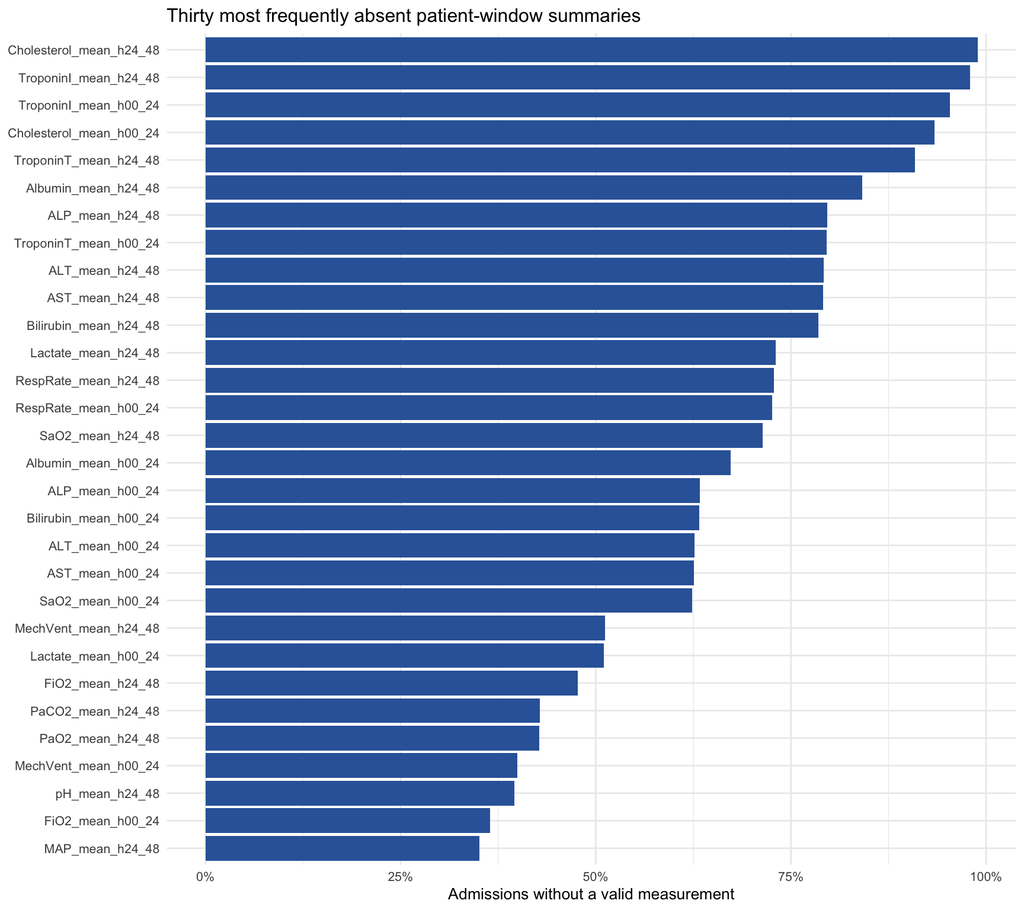

```r
mean_columns <- grep("_mean_h", names(wide), value = TRUE)
missing_rates <- tibble::tibble(
  feature = mean_columns,
  missing_fraction = colMeans(is.na(wide[mean_columns]))
) |>
  arrange(desc(missing_fraction))
ggplot(head(missing_rates, 30),
       aes(x = missing_fraction, y = reorder(feature, missing_fraction))) +
  geom_col(fill = "#3265a8") +
  scale_x_continuous(labels = scales::label_percent()) +
  labs(title = "Thirty most frequently absent patient-window summaries",
       x = "Admissions without a valid measurement", y = NULL) +
  theme_minimal(base_size = 10)
```

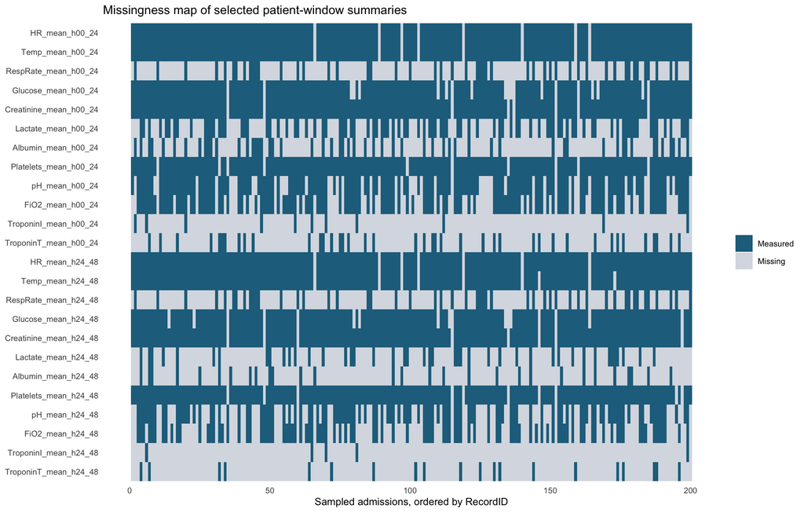

```r
selected_parameters <- c("HR", "Temp", "RespRate", "Glucose", "Creatinine",
                         "Lactate", "Albumin", "Platelets", "pH", "FiO2",
                         "TroponinI", "TroponinT")
selected_columns <- intersect(
  as.vector(outer(selected_parameters, c("h00_24", "h24_48"),
                  function(p, w) paste0(p, "_mean_", w))),
  names(wide)
)
set.seed(707)
sample_ids <- sample(wide$RecordID, min(200L, nrow(wide)))
wide_map <- wide |>
  filter(RecordID %in% sample_ids) |>
  arrange(RecordID) |>
  select(RecordID, all_of(selected_columns)) |>
  mutate(admission_index = row_number()) |>
  pivot_longer(all_of(selected_columns),
                names_to = "feature", values_to = "value") |>
  mutate(
    feature = factor(feature, levels = rev(selected_columns)),
    status = if_else(is.na(value), "Missing", "Measured")
  )
ggplot(wide_map, aes(x = admission_index, y = feature, fill = status)) +
  geom_tile() +
  scale_fill_manual(values = c(Missing = "#d9dce3", Measured = "#216e8c")) +
  labs(title = "Missingness map of selected patient-window summaries",
       x = "Sampled admissions, ordered by RecordID", y = NULL, fill = NULL) +
  theme_minimal(base_size = 10) +
  theme(panel.grid = element_blank())
```

The different patterns between the two windows matter: a variable may be measured only early, only late, or not at all. We preserve those distinctions and do not fill absent summaries with an overall mean at this exploratory stage.

## Is the missingness informative?

The following descriptive comparison asks whether in-hospital mortality differs between stays where a variable was ever validly measured and stays where it was not. It does not establish that measuring the variable changes mortality: the ordering decision may reflect patient condition and clinical practice.

```r
chosen_parameters <- c("HR", "Lactate", "Albumin", "TroponinI")
ever_measured <- long |>
  filter(Parameter %in% chosen_parameters, !is.na(Value)) |>
  distinct(RecordID, Parameter) |>
  mutate(measured = TRUE)
measurement_death <- tidyr::expand_grid(
  RecordID = outcomes$RecordID, Parameter = chosen_parameters
) |>
  left_join(ever_measured, by = c("RecordID", "Parameter")) |>
  mutate(measured = replace_na(measured, FALSE)) |>
  left_join(outcomes |> select(RecordID, `In-hospital_death`), by = "RecordID") |>
  group_by(Parameter, measured) |>
  summarise(
    admissions = n(), deaths = sum(`In-hospital_death` == 1),
    death_rate = deaths / admissions, .groups = "drop"
  ) |>
  mutate(death_rate = scales::percent(death_rate, accuracy = 0.1))
knitr::kable(measurement_death,
             caption = "Mortality by whether a variable was ever measured")
```

Mortality by whether a variable was ever measured

| Parameter | measured | admissions | deaths | death_rate |
| --- | --- | --- | --- | --- |
| Albumin | FALSE | 2385 | 251 | 10.5% |
| Albumin | TRUE | 1615 | 303 | 18.8% |
| HR | FALSE | 63 | 5 | 7.9% |
| HR | TRUE | 3937 | 549 | 13.9% |
| Lactate | FALSE | 1817 | 169 | 9.3% |
| Lactate | TRUE | 2183 | 385 | 17.6% |
| TroponinI | FALSE | 3795 | 497 | 13.1% |
| TroponinI | TRUE | 205 | 57 | 27.8% |

# Understanding the eventual Challenge assessment

No model is fitted or scored for Checkpoint 1. For a future binary mortality prediction, sensitivity is $TP/(TP+FN)$ and positive predictive value is $TP/(TP+FP)$. The Challenge’s first criterion is the **smaller** of these two numbers, so a high value of only one is insufficient. Its second criterion assesses predicted risks: patients are grouped into risk deciles and a modified Hosmer–Lemeshow discrepancy compares observed and expected deaths. The original Challenge divides that discrepancy by the spread between mean risk in the top and bottom deciles ($H/D$). These criteria concern future predictions, not the descriptive work in this report. See the [Challenge scoring description](https://physionet.org/content/challenge-2012/1.0.0/).

# AI-use statement

I used AI as an editing and learning aid while working with R and Quarto. Because `knitr` was new to me, I asked how R chunks are run and how their results appear in a rendered document. AI helped me understand less familiar choices such as `here` for repository-relative paths and chunk labels such as `#| label: check-inputs`. It also helped organize the *Data and analysis plan* section. I used AI to refine some descriptions that initially sounded too conversational and did not clearly connect the findings to the displayed results. The revised wording is more formal and states the observed patterns more precisely.

For the missingness map, I used AI feedback to review the tile layout, figure size, labels, theme, and colors, including the `geom_tile()` and `scale_fill_manual()` settings. AI also suggested retaining an additional bar chart because it ranks the widest gaps in measurement coverage across all variable-window summaries, whereas the tile map shows patterns for individual admissions. After discussing that distinction, I accepted the extra graph. When the report did not render, I used AI to inspect the error message and identify the Quarto cache issue. These interactions helped me understand unfamiliar tools and improve the report’s readability. A limitation is that suggestions can introduce complexity or overlook details in the data. To review the AI-generated code, I asked for explanations of unfamiliar R and Quarto choices, including here, knitr chunk labels, and package startup messages. I ran the report with Pixi and used AI-assisted checks to compare variable names with the original data and inspect the resulting tables, graphs, and CSV files. Those checks confirmed 4,000 unique admissions and identified an incorrect troponin variable name, which was corrected. This review helped me catch implementation errors.

# Data citations

Silva, I., Moody, G., Mark, R. G., & Celi, L. A. (2012). *Predicting Mortality of ICU Patients: The PhysioNet/Computing in Cardiology Challenge 2012* (version 1.0.0) [Data set]. PhysioNet. https://physionet.org/content/challenge-2012/1.0.0/.

Silva, I., Moody, G., Scott, D. J., Celi, L. A., & Mark, R. G. (2012). Predicting in-hospital mortality of ICU patients: The PhysioNet/Computing in Cardiology Challenge 2012. *Computing in Cardiology, 39*, 245–248. https://physionet.org/files/challenge-2012/1.0.0/papers/0245.pdf.